# El catálogo produce lo que menos se valora

StreamView Analytics · Informe para el Gerente de Contenidos

El catálogo produce *lo que menos se valora*

Diagnóstico de 31.991 títulos para decidir qué adquirir, producir y promocionar. Qué está funcionando, dónde hay una oportunidad que hoy no se ve, y qué hacer al respecto.

**Matías Retamal** · **Claudio González**◷ Lectura de 6 minutos

La pregunta

Lo que revisamos primero

El desajuste

El giro: dónde está la plata

Qué hacer

Este informe se lee de arriba hacia abajo, como una historia en cinco capítulos. Cada cifra que aparece está calculada a partir de los datos del catálogo, y cada gráfico responde una pregunta concreta de negocio. El código que lo respalda está oculto; los notebooks 01 a 03 muestran cómo se construyó cada paso.

01

Capítulo 1

¿Lo que producimos es lo que la audiencia valora?

Hoy las decisiones de contenido se toman sin una vista completa del catálogo. Esta es la pregunta que esa vista permite responder.

La pregunta

Lo que revisamos primero

El desajuste

El giro: dónde está la plata

Qué hacer

El Gerente de Contenidos decide, cada pocas semanas, qué títulos adquirir, cuáles producir y a cuáles darles promoción. Lo hace con buen criterio, pero sin poder mirar el catálogo completo de una vez: sin saber qué géneros y mercados reciben mejor evaluación, ni dónde el dinero invertido vuelve.

Este es el catálogo que analizamos:

31.991

títulos en el catálogo

16.000 películas · 15.991 series

6,71

nota media ponderada

sobre 20.980 títulos con votos suficientes

1,70×

retorno de la película típica

lo que recauda por cada dólar invertido · 3.540 películas con datos

46,2%

del catálogo es drama

14.773 títulos: el género dominante

Un catálogo que crece por inercia tiende a producir más de lo que ya produce. La pregunta es si eso que más produce coincide con lo que su audiencia mejor recibe.

La respuesta corta: no coinciden. Y la diferencia tiene un costo que se puede medir.

02

Capítulo 2

Antes de responder, revisamos los datos

Una conclusión vale lo que valen los datos que la sostienen. Por eso lo primero fue auditarlos.

La pregunta

Lo que revisamos primero

El desajuste

El giro: dónde está la plata

Qué hacer

El encargo original pedía varios análisis. Al revisar los datos, cuatro de ellos resultaron imposibles de hacer bien. Preferimos decirlo antes que presentar conclusiones que los datos no sostienen:

Duración ideal de un contenido

Clasificación por edad

La columna que debía traerla es una copia exacta de la nota. El dato no existe.

Evolución del catálogo en el tiempo

Hay exactamente 1.000 títulos por año: cualquier tendencia sería un efecto del muestreo.

Retención y engagement

Los datos de usuarios y reproducciones nunca llegaron. Medimos recepción, no consumo.

1

voto tiene el título mejor evaluado del catálogo, si se mira la nota sin ajustar.

Por eso toda nota de este informe está ponderada por la cantidad de votos: un 10 con un voto no le gana a un 8,4 con doce mil.

Decisión

Preferimos responder menos preguntas, pero que cada respuesta se sostenga. Las cuatro que descartamos quedan documentadas con la evidencia que lo demuestra.

03

Capítulo 3

Lo que más se produce no es lo que mejor se recibe

¿Dónde está concentrado el catálogo, y cómo evalúa la audiencia eso que más hay?

La pregunta

Lo que revisamos primero

El desajuste

El giro: dónde está la plata

Qué hacer

1 de cada 3

películas del catálogo es de terror o suspenso.

4.387 títulos distintos. Y son justamente los dos géneros peor evaluados: 5,89 y 6,15 de nota.

Títulos en el catálogo de películas

Terror y suspenso

4.387

Documental, musical e histórico

1.546

El grupo mejor evaluado tiene un tercio del volumen y 0,77 puntos más de nota.

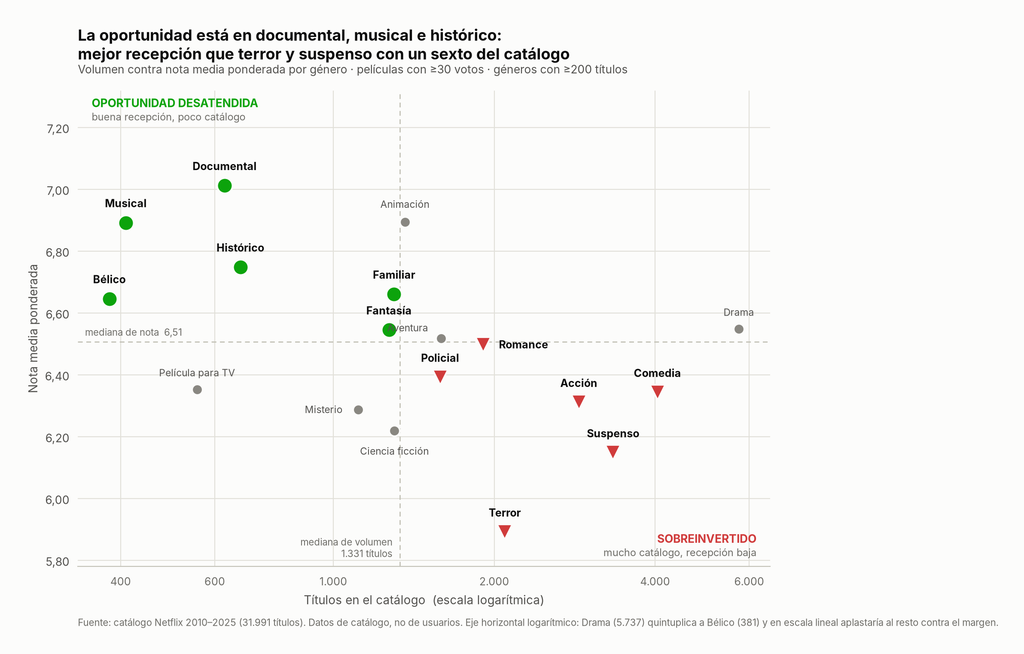

**Cada punto es un género.** A la derecha, los que más se producen; arriba, los mejor evaluados. Abajo a la derecha, mucho catálogo y baja recepción. Arriba a la izquierda, lo contrario: la oportunidad desatendida.

El mismo desajuste aparece al mirar de dónde viene el contenido.

Títulos por país de origen, con su nota media

Estados Unidos · nota 6,56

9.773

Japón · nota 7,21

2.147

Hallazgo

Estados Unidos aporta 4,6 veces los títulos de Japón, y de los 24 países con más de 150 títulos, 14 reciben mejor nota. Japón y Corea del Sur (7,11) encabezan la recepción. No dice que el contenido asiático sea mejor: dice que, dentro de este catálogo, está subrepresentado respecto de cómo se recibe.

04

Capítulo 4

El giro: dónde está realmente la plata

¿Todo lo mal evaluado es un error? ¿Todo lo bien evaluado es buen negocio?

La pregunta

Lo que revisamos primero

El desajuste

El giro: dónde está la plata

Qué hacer

Si nos hubiéramos detenido en el capítulo anterior, la recomendación obvia habría sido producir menos terror. Habría sido un error. Antes de recomendar, cruzamos la evaluación de la audiencia con lo que cada película costó y lo que recaudó.

Presupuesto mediano por película, en millones de dólares

Aventura

60

Animación

50

Terror

7

Lo inesperado

Terror es el género más barato de producir del catálogo, y aun así la película de terror típica recauda 2,03 veces lo que costó, más que la del catálogo en general. Su volumen no es un descuido: es una apuesta de costo, y la nota baja es el precio conocido de esa apuesta.

La pregunta útil, entonces, no es qué géneros tienen mala nota, sino qué pasa con la plata según la nota. Esta es la respuesta, en películas reales del catálogo:

Películas con nota **bajo 6**

53de cada 100 **no recuperan** lo que costaron

Películas con nota **sobre 7**

21de cada 100 **no recuperan** lo que costaron

La nota predice la plata. El presupuesto, no.

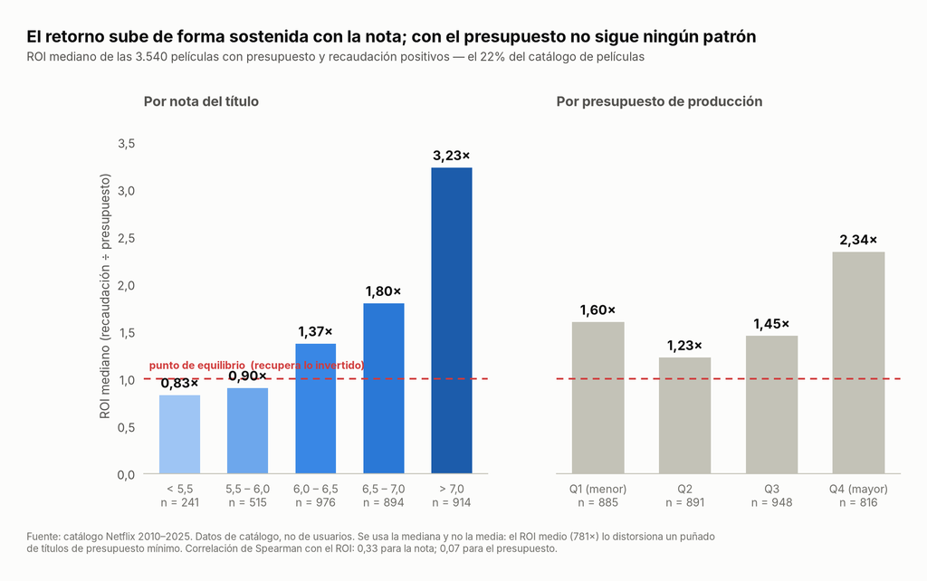

**A la izquierda**, el retorno sube de forma sostenida con la nota: de 0,83× a 3,23×. **A la derecha**, el mismo indicador según cuánto se gastó: no sigue ningún patrón.

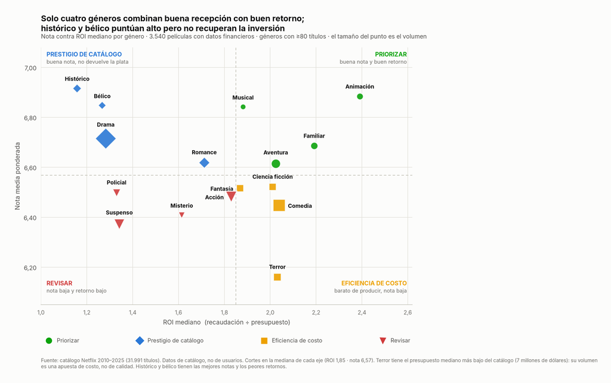

**Los cuatro cuadrantes del catálogo.** Arriba a la derecha, lo que conviene priorizar: buena nota y buen retorno a la vez.

Por qué no recomendamos lo mejor evaluado

Histórico y bélico tienen las mejores notas entre las películas con datos financieros (6,92 y 6,85) y los peores retornos (1,16× y 1,27×). Recomendarlos solo por su nota sería recomendar prestigio, no negocio.

05

Capítulo 5

Tres decisiones para el próximo año

¿Qué haría distinto el Gerente de Contenidos a partir de mañana?

La pregunta

Lo que revisamos primero

El desajuste

El giro: dónde está la plata

Qué hacer

1

Reequilibrar la adquisición hacia los géneros que ganan dos veces

Animación, familiar, aventura y musical son los únicos cuatro géneros por sobre la mediana en recepción **y** en retorno. En animación, el más fuerte, la película típica recauda 2,39 veces lo invertido. No se trata de dejar de producir terror, que cumple una función de costo, sino de mover el margen de crecimiento.

Meta: **del 22,4% al 30% de las nuevas adquisiciones de películas en 12 meses**Evidencia: capítulo 4, cuadrantes del catálogo

2

Abrir una línea de adquisición dedicada a Japón y Corea del Sur

Encabezan la recepción del catálogo (7,21 y 7,11) y hoy son una fracción pequeña de las películas. Es una apuesta por contenido que la audiencia ya demostró valorar.

Meta: **del 11,6% al 18% de las adquisiciones de películas en 12 meses**Evidencia: capítulo 3, países de origen

3

Condicionar el presupuesto a la recepción esperada, y no al revés

Ningún proyecto del tramo de mayor presupuesto sin evidencia de recepción comparable: equipo, género o antecedentes con nota sobre 6,5. Hoy 37 de cada 100 películas no recuperan lo que costaron.

Meta: **bajar del 36,7% al 30% la proporción de películas que no recuperan su presupuesto**Evidencia: capítulo 4, retorno según nota

Lo que todavía no sabemos

Estas conclusiones son sobre la composición del catálogo, no sobre el comportamiento de la audiencia. Sabemos qué títulos reciben mejor nota de quienes los califican; no sabemos cuántas personas los vieron ni cuántas se quedaron por ellos. Con datos de reproducción, la siguiente pregunta sería si la buena recepción se traduce en retención.

Si se quedan con una sola idea

La nota predice la plata. El presupuesto, no.

Para cada decisión nueva de contenido, el dashboard permite comprobar en segundos en qué cuadrante cae. Es la herramienta con la que estas tres decisiones se ejecutan.

## Anexo · Para profundizar

Dos análisis que respaldan el diagnóstico pero no cambian la recomendación, y dónde encontrar el detalle de cada paso.

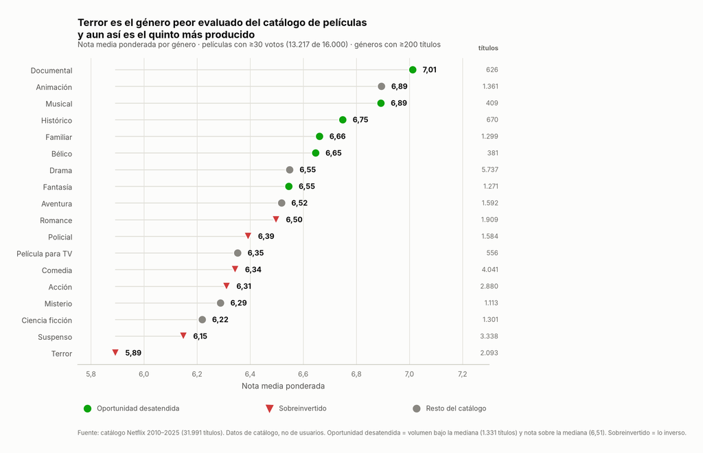

**Nota por género, solo películas.** El detalle del capítulo 3, género por género.

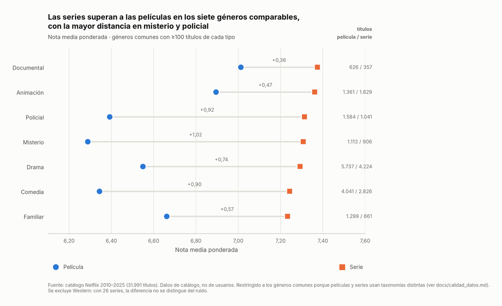

**Película contra serie.** Las series superan a las películas en los 7 géneros comparables. Lectura con reserva: quien califica una serie ya invirtió horas en ella, así que las dos notas no miden exactamente lo mismo.

**Cómo se construyó cada parte**

| Notebook | Qué contiene |
| --- | --- |
| `01_auditoria_datos` | Los diez hallazgos sobre la calidad de los datos, verificados en código |
| `02_limpieza_integracion` | Cómo se unieron películas y series en un solo catálogo |
| `03_analisis_exploratorio` | Los seis gráficos y por qué cada uno es ese gráfico |

La justificación de cada decisión de diseño está en `docs/decisiones_diseno.md`, y la auditoría completa de los datos en `docs/calidad_datos.md`.